BayesEval · RQ 3 · confound-aware re-analysis

# Does SPD prompting help calibration?

The paper says SPD helps the worst-calibrated and backfires on the best. That reading is a percentage illusion. Here is what the data say once you compare like with like.

**Yes — for overconfident models, and robustly so.** The two dramatic "backfires" (+89%, +335%) are artefacts. The only genuine degradation is small.

7 / 12large, standard-independent gains

~½ECE cut on MedEval

1robust backfire (Llama · LifeEval)

0of the paper's two backfires survive

The effect size

## Paired ΔECE, measured like-for-like

SPD − DCE change in calibration error, on the four shared difficulty levels, item-paired, full data (lenient parse). Negative is better. Each cell shows two calibration standards, with 95% bootstrap CIs. Where they disagree, that disagreement is the finding.

stratified Δ (conditional calibration) pooled Δ (marginal calibration) improves worsens null (CI crosses 0)

MedEval — differential diagnosis

Gemini 2.5 Flash

-0.332-0.332

Claude Haiku 4.5

-0.305-0.305

Llama 4 Maverick

-0.297-0.297

GPT-5.4 Mini

-0.288-0.288

WGD — weight guessing

Gemini 2.5 Flash

-0.218-0.228

Llama 4 Maverick

-0.117-0.132

Claude Haiku 4.5

-0.048-0.004

GPT-5.4 Mini

-0.006+0.035

LifeEval — lifespan windows

Gemini 2.5 Flash

-0.214-0.214

Claude Haiku 4.5

-0.055+0.113

GPT-5.4 Mini

-0.028-0.021

Llama 4 Maverick

+0.044+0.069

−0.30 −0.15 0 +0.10

ΔECE

**How this chart was made.** Each of the 12 rows is one model tested in one domain. For every question answered under *both* prompts, we recorded the calibration error (ECE) under the ordinary DCE prompt and under the SPD prompt, restricted to the four difficulty levels both prompts share, and using the full data (answers parsed leniently so none are silently dropped). We then took the difference SPD − DCE. A bar to the **left** of the centre line (teal) means SPD made calibration **better**; to the **right** (clay) means **worse**; **grey** means the 95% confidence interval crosses zero, so the change can't be distinguished from no change. The thin whisker on each bar is that 95% interval, from a 2000-resample paired bootstrap. Each row carries *two* bars because calibration was scored two ways — the thicker bar is the "stratified" (difficulty-conditional) standard, the thinner one the "pooled" (marginal) standard, both defined in Methods below. The two figures on the right are those two ΔECE values.

Cell by cell

## What actually happens

### GPT-5.4 Mini · WGD the "+89%" backfire → null

Not significant under either standard (pooled +0.035 p=.09; stratified −0.006 p=.71). Its honest DCE calibration already sat at SPD's WGD floor (~0.08–0.10) — nothing to fix, nothing broken.

### Claude Haiku 4.5 · LifeEval the "+335%" backfire → metric split

Significantly **worse** under pooled ECE (+0.113) yet significantly **better** under stratified (−0.055) — same cell, opposite signs. DCE only wins marginally because pooling lets its per-difficulty errors cancel. Not "SPD hurts a well-calibrated model."

### Llama 4 Maverick · LifeEval the one robust backfire

Why the paper's numbers misled

## Four confounds, each verified

C1 · percentage inflation

### Tiny denominators explode

ΔECE% divides by the DCE baseline. The two "backfires" sit on the two smallest baselines in the table, so a modest absolute move becomes "+89%" / "+335%." Percent is not an effect size.

C2 · pooling cancellation

### Standard ECE hides miscalibration

Binning by confidence alone lets over- and under-confidence at different difficulties cancel. DCE sweeps 20 levels, SPD 4. Stratified, Claude/LifeEval DCE goes 0.05 → **0.23**.

C3 · answer-parse dropout

### Half of Claude's DCE was discarded

Plain `to_numeric` drops "77 years" → NaN. Claude/LifeEval kept only **52%** of DCE rows vs 100% of SPD. We re-score with the lenient extractor to recover them.

C4 · difficulty mismatch

### The modes tested different mixes

DCE's 20 difficulty levels vs SPD's 4 make the marginal mixes differ. We restrict DCE to the shared {1,5,10,20} and pair on item identity (photo / age+sex / patient).

Mechanism

## SPD's calibration is set by task structure

SPD's scored confidence is the **modal-bin mass** — pinned behaviourally by spreading probability across bins, roughly domain-fixed (≈0.30 across all WGD models). Its residual miscalibration is dominated by how far that level sits from the domain's base-rate accuracy (r = 0.99). So SPD calibrates worst exactly where its bin-pinned confidence mismatches the base rate — LifeEval — not where the model was "well-calibrated."

structural gap · one model×domain cell · SPD rows i = 1…N

gap = | m̄ − ȳ | = | (1/N) Σ<sub>i</sub> ( conf<sub>i</sub> − y<sub>i</sub> ) | = | mean over-confidence |  
where m̄ = (1/N) Σ conf<sub>i</sub> (mean modal-bin mass) · ȳ = (1/N) Σ y<sub>i</sub> (mean true_probability = base-rate accuracy)

It is **mean-then-absolute**: the signed over/under-confidence is averaged first, and the absolute value is taken only at the end — so it is SPD's *net* miscalibration, and by the triangle inequality a lower bound on ECE (ECE ≥ gap). In code: abs(mean_conf − accuracy) on the SPD frame.

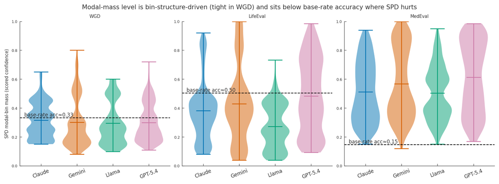

**How this was made.** Under SPD the model returns a whole probability distribution over answer bins; the number that actually gets graded as its "confidence" is the probability it placed on its single most-likely bin. This plot takes that modal-bin probability for every SPD question and draws its distribution as a violin — one violin per model, in three panels for the three domains. The vertical axis is that confidence (0 to 1). The dashed black line in each panel is the domain's average base-rate accuracy: how often the modal answer is actually correct.

**What it shows.** In **WGD** all four models pile into a narrow band around 0.30 — it barely matters which model it is. In **LifeEval** the models spread out (Llama ≈ 0.27, GPT ≈ 0.48) and mostly sit *below* the accuracy line. In **MedEval** every model sits far *above* its accuracy line.

**What we conclude.** SPD's confidence is set mostly by the binning scheme, not by the model's genuine belief — that is why the WGD band is so tight and model-agnostic. Whether SPD ends up well-calibrated then comes down to how that structural confidence level lines up with the domain's real accuracy: matched in WGD (well-calibrated), too low in LifeEval (under-confident — the root of the LifeEval trouble cells), and too high in MedEval (still over-confident, though far less so than DCE).

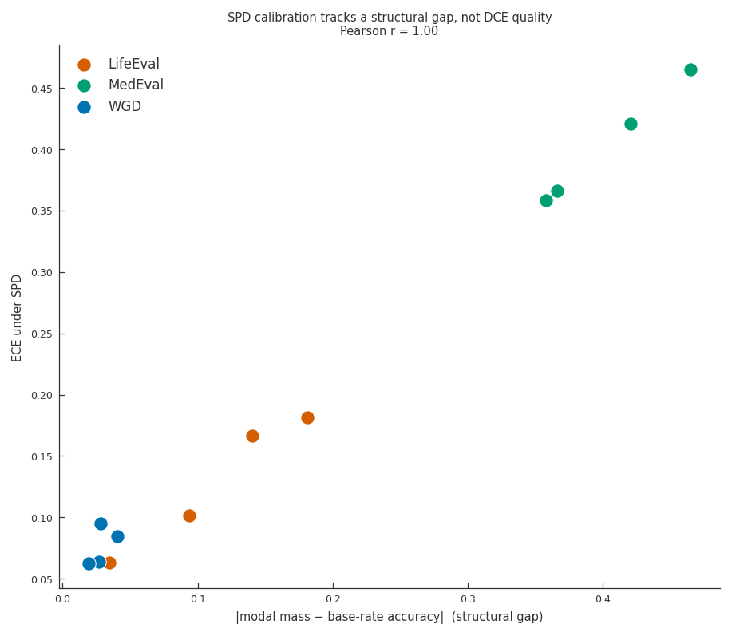

**How this was made.** For each of the 12 model–domain cells we computed two numbers. The horizontal axis is the "structural gap": the absolute distance between SPD's average modal-bin confidence and the domain's base-rate accuracy — i.e. how far off SPD's typical confidence is from the truth, on average. The vertical axis is SPD's actual calibration error (ECE). Each dot is one cell, coloured by domain.

**What it shows.** The dots fall almost exactly on a rising straight line (Pearson r = 0.99): WGD cells cluster at the bottom-left (small gap, small error), LifeEval in the middle, MedEval at the top-right (large gap, large error).

**What we conclude.** SPD's calibration error is almost completely explained by this single structural quantity — the mismatch between its bin-pinned confidence and the base rate — and essentially not at all by how well-calibrated the model had been under DCE. (Some of the tightness is definitional, since average-confidence-minus-accuracy is mathematically related to ECE; the claim it supports is that the *dominant* driver is a domain-structural offset, not model skill.)

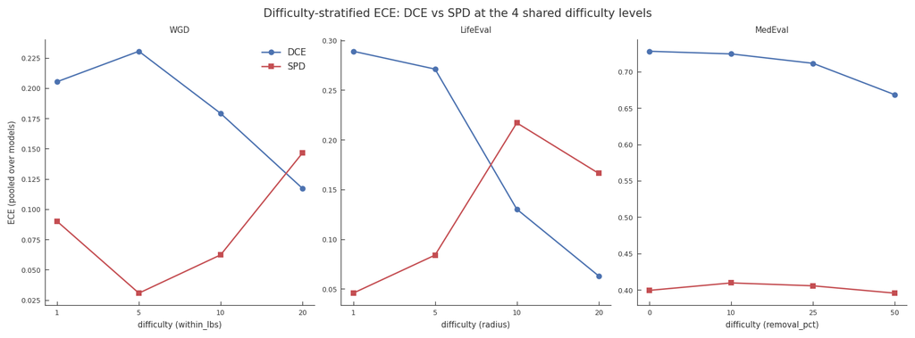

**How this was made.** Each domain was split into its four difficulty levels (the horizontal axis: weight tolerance for WGD, age-window radius for LifeEval, percent of the diagnosis list removed for MedEval — smaller/harder toward one end). At each level we computed the calibration error (ECE) separately, pooled across all four models: a blue line for the ordinary DCE prompt, a red line for the SPD prompt.

**What we conclude.** Two things. First, DCE's flatteringly low pooled ECE is an illusion: its per-difficulty errors are large but cancel out when you average confidence across levels — which is exactly the cancellation the "stratified" metric refuses to allow, and why the two metrics disagree for LifeEval. Second, SPD's advantage, while real on average, is not uniform across difficulty (hence the crossings) — the honest nuance behind the headline.

Methods, in depth

## The two ways to score calibration

Both "techniques" are the **same primitive fed different rows** — nothing else differs. Each scored row carries a confidence conf (DCE scalar, or SPD modal-bin mass), a ground-truth y, and a difficulty label. One function turns those into a number:

compute_ece(conf, y)

1 bin rows into 11 fixed confidence bins [0,.1) … [.9,1) [1.0]  
2 per bin b: n<sub>b</sub>=count, c̄<sub>b</sub>=mean conf, ȳ<sub>b</sub>=mean y  
3 **ECE = Σ<sub>b</sub> (n<sub>b</sub>/N) · |ȳ<sub>b</sub> − c̄<sub>b</sub>|**

One wrinkle in the inputs: y is hit/miss (0 or 1) for WGD but a *continuous* correctness probability for LifeEval and MedEval — so a bin's "accuracy" is a hit-rate in one domain and a mean probability in the others.

Technique A

### Pooled ECE — the paper's metric

**Feed it:** all rows together, one bin partition, one number. **Estimates:** *marginal* calibration — "over my whole track record, when I say p, is the outcome p?"

Steelman · textbook, pre-registered, no auxiliary variable, lowest variance. Exactly right if a consumer only wants "discount an 0.8 to 0.8."

Strawman · blind to a model that is overconfident on hard items and underconfident on easy ones — those cancel inside a confidence bin, which is the regime here (overconfidence rises with difficulty).

Justified when the decision is marginal or confidence is uncorrelated with difficulty. Not when confidence tracks difficulty and decisions condition on the item.

Technique B

### Stratified — conditional on difficulty

**Feed it:** rows split by difficulty; ECE within each stratum, then count-weighted average. **Estimates:** *conditional* calibration — "within a difficulty, when I say p, is the outcome p?"

Steelman · calibration should hold conditional on what the decider knows; conditioning on a designed, observable difficulty axis removes an identifiable cancellation channel. Strictly stronger than pooled.

Strawman · removes cancellation only along the axis you stratify (a lower bound on true miscalibration); fewer rows/bin → upward small-sample bias; a researcher degree of freedom; changes the estimand.

Justified when a covariate correlated with confidence and outcome is observable and strata are large — all true here.

### Why they can disagree — the cancellation identity

Because |mean| ≤ mean|·|, stratified ECE ≥ pooled ECE *always*, and the gap is exactly the cross-difficulty cancellation. One confidence bin (conf ≈ 0.5):

| difficulty | conf | outcome y | within-stratum gap |
| --- | --- | --- | --- |
| hard | 0.5 | 0.3 | 0.2 |
| hard | 0.5 | 0.3 | 0.2 |
| easy | 0.5 | 0.7 | 0.2 |
| easy | 0.5 | 0.7 | 0.2 |

**Pooled:** ȳ = 0.5 = c̄ → ECE 0 ("perfectly calibrated"). **Stratified:** ECE 0.2. DCE emits difficulty-varying confidence (much cancellation — Claude/LifeEval pooled 0.05 → stratified 0.23); SPD emits near-flat modal mass (pooled ≈ stratified). That differential is the whole reason Claude/LifeEval flips sign.

**Does the choice even matter?** For **11 of 12 cells, no** — both techniques give the same verdict. Exactly **one** cell genuinely flips direction: Claude Haiku 4.5 · LifeEval, the very cell the paper spotlighted.

So the metric debate changes one cell's sign and sharpens the diagnosis of the illusory backfires — but the bottom line is invariant: SPD is a net calibration win for overconfident models, with one small real backfire. The deep dive didn't overturn the quick read ("imperfect, but it works") — it proved which single claim is metric-contingent, and that nothing else is.

Red-team

## What could break this — and why it doesn't

- **Stratified-ECE small-sample bias?** Debiased each ECE against its perfect-calibration null (simulate outcomes ~ Bernoulli(conf), subtract expected bias). Every ΔECE moves ≤0.015 and no sign flips — the stratified DCE inflation is *real miscalibration*, not bin noise.
- **Parse dropout driving it?** Lenient re-scoring uses 100% of rows and *strengthens* the Claude/LifeEval pooled backfire (+0.025 → +0.113); the verdict isn't an artefact of discarded data.
- **Metric cherry-picking?** Both pooled and stratified are shown. The robust conclusions hold under both; only the sign of the small Claude/LifeEval effect is standard-dependent, and we say so.
- **Small n.** 12 cells (4 models × 3 domains). Directional claims are robust; fine cross-domain ordering is not. Percentile bootstrap CIs, 2000 resamples, paired on item identity.

For the paper

## Recommended restatement of RQ 3

SPD prompting significantly improves calibration for overconfident models — roughly halving ECE on MedEval and cutting it sharply on WGD (7 of 12 cells show large, standard-independent gains). Its effect size is governed by task structure — the gap between SPD's bin-pinned modal confidence and a domain's base-rate accuracy — not by the model's DCE calibration. The two cells reported as dramatic "backfires" are artefacts of percentage inflation, pooling cancellation, and answer-parse dropout: GPT-5.4 Mini/WGD is a null, and Claude/LifeEval worsens only marginal calibration while improving conditional calibration. The one robust degradation is small (Llama 4 Maverick/LifeEval), where SPD's modal mass turns underconfident against a high base rate.

Report **absolute paired ΔECE with 95% CIs under both a pooled and a difficulty-stratified standard** as the effect size; keep percent change only as secondary context.

Reproducible from analysis/spd_reanalysis.py on branch spd-reanalysis; reuses scoring.get_scorer, compute_ece, and murphy_decomposition, and reproduces the repo's build_summary ECE column exactly. Full write-up: analysis/reports/spd_reanalysis.md.